# R: Generalized hierarchical ordered threshold models.

| hopit {hopit} | R Documentation |
| --- | --- |

## Generalized hierarchical ordered threshold models.

### Description

The ordered response data classifies a measure of interest into ordered categories collected during a survey. For examle, if the dependent variable were a happiness rating, then a respondent typically answers a question like: “Taking all things together, would you say you are ...? “ and then selects from response options along the lines of: "very happy", "pretty happy", "not too happy", "very unhappy" (Liao et al. 2005). Similarly if interviewees are asked to evaluate their health in general (e.g. “Would you say your health is ...?”) they may choose among several categories, such as "very good", "good", "fair", "bad", and "very bad" (King et al. 2004; Jürges 2007; Rebelo and Pereira 2014). In political sciences a respondent may be asked for an opinion about recent legislation (e.g. “Rate your feelings about the proposed legislation") and asked to choose among categories like: "strongly oppose", "mildly oppose", "indifferent", "mildly support", "strongly support" (Greene and Hensher 2010). It is easy to imagine other multi-level ordinal variables that might be used during a survey and to which the methodology described below could be applied to.

Practically, it is assumed that when responding to a survey question about their general happiness, health, feeling, attitude or other status, participants assess their true value of this unobserved continuous variable, and project it to a provided discrete scale. The thresholds that each individual uses to categorize their true status into a specific response option may be affected by the choice of a reference group, earlier life experiences, and cross-cultural differences in using scales, and thus, may differ across individuals depending on their gender, age, cultural background, education, and personality traits, among other factors.

From the reporting-styles modeling perspective, one of the main tasks is to compute this continuous estimate of individuals’ underlying, latent measure based on several specific characteristics of the considered response (e.g. health variables or happiness variables) and accounting also for variations in reporting across socio-demographic and cultural groups. More specifically, to build the latent, underlying measure a generalized hierarchical ordered threshold model is fitted, which regresses the reported status/attitude/feeling on two sets of independent variables (Boes and Winkelmann 2006; Greene et al. 2014). When a dependent reported ordered variable is self-rated health status then the first set of variables (health variables) assesses individuals’ specific aspects of health, and might include chronic conditions, mobility level, difficulties with a range of daily activities, performance on grip strength test, anthropometric measures, lifestyle behaviors, etc. Using the second set of independent variables (threshold variables), the model also adjusts for the differences across socio-demographic and cultural groups like cultural background, gender, age, education, etc. (King et al. 2004; Jürges 2007).

Ordered threshold models are used to fit ordered categorical dependent variables. The generalized ordered threshold models (Ierza 1985; Boes and Winkelmann 2006; Greene et al. 2014) are an extension to the ordered threshold models (McKelvey and Zavoina 1975). In the latter models, the thresholds are constant, whereas generalized models allows thresholds to be dependent on covariates. Greene and Hensher (2010); Greene et al. (2014) pointed out that also thresholds must be ordered so that a model has a sense. This motivated Greene and coauthors to call this models *HOPIT*, which stands for hierarchical ordered probit models.

The fitted *hopit* model is used to analyse reporting styles. See `standardizeCoef`, `latentIndex`, `getCutPoints`, and `getLevels`.

### Usage

```
hopit(latent.formula, thresh.formula = ~1, crossinter.formula = ~1,
  data, decreasing.levels, start = NULL, overdispersion = FALSE,
  design = list(), weights = NULL, link = c("probit", "logit"),
  control = list())
```

### Arguments

[output not shown]

### Details

The function fits generelaized hierarchical ordered threshold models.

`latent.formula` models latent variable. if the response variable is self-rated health then latent measure can depend on different health conditions and diseases (latent variables are called health variables). Latent variables are modeled with parallel regression assumption. According to the assumption, coefficients, which describe the relationship between lowest and all higher response categories, are the same as those coefficients, which describe the relationship between another (e.g. adjacent) lowest and the remaining higher response categories. The predicted latent variable is modeled as a linear function of health variables and corresponding coefficients.

`thresh.formula` models threshold variable. The thresholds (cut points, `alpha`) are modeled by threshold variables `gamma` and intercepts `lambda`. It is assumed that they model contextual characteristics of the respondent (e.g. country, gender, age, etc. ). Threshold variables are modeled without parallel regression assumption, thus each threshold is modeled by a variable independently (Boes and Winkelmann 2006; Greene et al. 2014). `hopit`() function uses parametrization of tresholds proposed by Jürges (2007).

`decreasing.levels` it is the logical that determines the ordering of levels of the categorical response variable. It is always good to check first the ordering of the levels before starting (see example 1)

For more details please see the package vignette: "introduction_to_hopit".

### Value

a `hopit` object used by other functions and methods. The object is a list with following components:

| `control` | a list with control parameters. See `hopit.control`. |
| --- | --- |
| `link` | the used link funtion. |
| `hasdisp` | logical, was overdispersion modeled? |
| `latent.formula` | used latent formula. |
| `latent.mm` | latent model matrix. |
| `latent.terms` | used latent variables. |
| `thresh.formula` | used threshold formula. |
| `thresh.mm` | threshold model matrix. |
| `thresh.extd` | threshold extended model matrix. |
| `thresh.terms` | used threshold variables. |
| `thresh.no.cov` | logical, are gamma parameters present? |
| `parcount` | 3-element vector with number of parmeters for latent latent variable (beta), threshold intercept (lambda), and threshold covariates (gamma). |
| `coef` | a vector with coefficients. |
| `coef.ls` | coefficients as a list. |
| `start` | vector with starting vlues of coefficients. |
| `alpha` | estimated individual-specific thresholds. |
| `y_i` | the response variable. |
| `y_latent_i` | predicted latent measure. |
| `Ey_i` | predicted categorical response. |
| `J` | the number of response levels. |
| `N` | the number of observations. |
| `deviance` | deviance. |
| `LL` | log likelihood. |
| `AIC` | AIC for models without survey design. |
| `vcov` | variance-covariance matrix. |
| `hessian` | a Hessian matrix. |
| `estfun` | gradient of the log likelihood function at estimated coefficient values. |
| `YYY1,YYY2,YY3` | internal objects used for calculation of gradient and Hessian functions. |
| `use.weights,vcov.basic,glm.start,glm.start.ls` | other internal objects. |

### Author(s)

Maciej J. Danko

### References

Boes S and Winkelmann R (2006). “Ordered response models.” *Allgemeines Statistisches Archiv*, **90**(1), pp. 167–181. ISSN 1614-0176, doi: 10.1007/s10182-006-0228-y.

Greene W and Hensher D (2010). *Modeling Ordered Choices*. Cambridge University Press. https://EconPapers.repec.org/RePEc:cup:cbooks:9780521142373.

Greene W, Harris MN, Hollingsworth B and Weterings TA (2014). “Heterogeneity in Ordered Choice Models: A Review with Applications to Self-Assessed Health.” *Journal of Economic Surveys*, **28**(1), pp. 109-133. doi: 10.1111/joes.12002.

Ierza JV (1985). “Ordinal probit: A generalization.” *Communications in Statistics - Theory and Methods*, **14**(1), pp. 1-11. ISSN 0361-0926, doi: 10.1080/03610928508828893, https://doi.org/10.1080/03610928508828893.

Jürges H (2007). “True health vs response styles: exploring cross-country differences in self-reported health.” *Health Economics*, **16**(2), pp. 163-178. doi: 10.1002/hec.1134.

King G, Murray CJL, Salomon JA and Tandon A (2004). “Enhancing the Validity and Cross-Cultural Comparability of Measurement in Survey Research.” *American Political Science Review*, **98**(1), pp. 191–207. doi: 10.1017/S000305540400108X.

Liao P, Fu Y and Yi C (2005). “Perceived quality of life in Taiwan and Hong Kong: an intra-culture comparison.” *Journal of Happiness Studies*, **6**(1), pp. 43–67. ISSN 1573-7780, doi: 10.1007/s10902-004-1753-6.

McKelvey RD and Zavoina W (1975). “A Statistical Model for the Analysis of Ordinal Level Dependent Variables.” *Journal of Mathematical Sociology*, **4**(1), pp. 103–120.

Rebelo LP and Pereira NS (2014). “Assessing health endowment, access and choice determinants: Impact on retired Europeans' (in)activity and quality of life.” *Social Indicators Research*, **119**(3), pp. 1411-1446. doi: 10.1007/s11205-013-0542-1.

### See Also

`coef.hopit`, `profile.hopit`, `hopit.control`, `anova.hopit`, `vcov.hopit`, `logLik.hopit`, `AIC.hopit`, `summary.hopit`, `svydesign`,  
For reporting styles analysis see:  
`standardizeCoef`, `latentIndex`, `getCutPoints`, `getLevels`.

### Examples

```r
# DATA
data(healthsurvey)

# first determine the order of levels of dependent variable
levels(healthsurvey$health)
```

```
## [1] "Excellent" "Very good" "Good"      "Fair"      "Poor"
```

```r
# Example 1 ---------------------

# the order is decreasing (from the best health to the worst health)
# so we set: decreasing.levels = TRUE
# fitting the model:
model1 <- hopit(latent.formula = health ~ hypertension + high_cholesterol +
                heart_attack_or_stroke + poor_mobility + very_poor_grip +
                depression + respiratory_problems +
                IADL_problems + obese + diabetes + other_diseases,
              thresh.formula = ~ sex + ageclass + country,
              decreasing.levels = TRUE,
              control = list(trace = FALSE),
              data = healthsurvey)

# summarize the fit:
summary(model1)
```

```
## Formula (latent variables):
## health ~ hypertension + high_cholesterol + heart_attack_or_stroke +
##     poor_mobility + very_poor_grip + depression + respiratory_problems +
##     IADL_problems + obese + diabetes + other_diseases
## Formula (threshold variables): ~sex + ageclass + country
## Link: probit
## Number of cases: 10000
## Response levels: Excellent, Very good, Good, Fair, Poor
##
## Robust SE were used (sandwich estimator of varcov).
##
##                            Estimate Std. Error z value Pr(>|z|)
## hypertensionyes            0.184753   0.024943    7.41  1.3e-13 ***
## high_cholesterolyes        0.089726   0.029389    3.05  0.00227 **
## heart_attack_or_strokeyes  0.346598   0.031829   10.89  < 2e-16 ***
## poor_mobilityyes           0.703465   0.035698   19.71  < 2e-16 ***
## very_poor_gripyes          0.514244   0.125004    4.11  3.9e-05 ***
## depressionyes              0.249983   0.024060   10.39  < 2e-16 ***
## respiratory_problemsyes    0.378635   0.033486   11.31  < 2e-16 ***
## IADL_problemsyes           0.592623   0.036545   16.22  < 2e-16 ***
## obeseyes                   0.190419   0.033357    5.71  1.1e-08 ***
## diabetesyes                0.328391   0.040264    8.16  3.3e-16 ***
## other_diseasesyes          0.329370   0.023977   13.74  < 2e-16 ***
## (L).1|2                   -0.505278   0.047143  -10.72  < 2e-16 ***
## (L).2|3                   -0.191826   0.047345   -4.05  5.1e-05 ***
## (L).3|4                    0.021154   0.038157    0.55  0.57932
## (L).4|5                   -0.193869   0.060239   -3.22  0.00129 **
## (G).sexwoman.1|2           0.016492   0.030807    0.54  0.59243
## (G).sexwoman.2|3           0.015217   0.034332    0.44  0.65760
## (G).sexwoman.3|4           0.028852   0.028468    1.01  0.31083
## (G).sexwoman.4|5           0.113136   0.050271    2.25  0.02442 *
## (G).ageclass60-69.1|2     -0.024798   0.034579   -0.72  0.47329
## (G).ageclass60-69.2|3      0.052028   0.040384    1.29  0.19762
## (G).ageclass60-69.3|4      0.055168   0.035914    1.54  0.12452
## (G).ageclass60-69.4|5      0.172093   0.065102    2.64  0.00821 **
## (G).ageclass70-79.1|2     -0.313800   0.045050   -6.97  3.3e-12 ***
## (G).ageclass70-79.2|3      0.168225   0.047396    3.55  0.00039 ***
## (G).ageclass70-79.3|4      0.178808   0.037503    4.77  1.9e-06 ***
## (G).ageclass70-79.4|5      0.228992   0.066599    3.44  0.00059 ***
## (G).ageclass80+.1|2       -0.314901   0.073926   -4.26  2.0e-05 ***
## (G).ageclass80+.2|3        0.143923   0.075028    1.92  0.05508 .
## (G).ageclass80+.3|4        0.169191   0.049725    3.40  0.00067 ***
## (G).ageclass80+.4|5        0.219412   0.075968    2.89  0.00387 **
## (G).countryY.1|2           0.221107   0.044058    5.02  5.2e-07 ***
## (G).countryY.2|3          -0.018311   0.047870   -0.38  0.70208
## (G).countryY.3|4           0.205206   0.035144    5.84  5.3e-09 ***
## (G).countryY.4|5           0.038362   0.054718    0.70  0.48325
## (G).countryZ.1|2           0.794200   0.044318   17.92  < 2e-16 ***
## (G).countryZ.2|3          -0.051216   0.049328   -1.04  0.29915
## (G).countryZ.3|4          -0.004189   0.042564   -0.10  0.92160
## (G).countryZ.4|5           0.127667   0.074071    1.72  0.08478 .
## ---
## Signif. codes:  0 '***' 0.001 '**' 0.01 '*' 0.05 '.' 0.1 ' ' 1
## Theta: 1
## Log-likelihood: -12538.09
## Deviance: 25076.19
## AIC: 25154.19
```

```r
# extract parameters in a form of list
cm1 <- coef(model1, aslist = TRUE)

# names of returned coefficients
names(cm1)
```

```
## [1] "latent.params" "thresh.lambda" "thresh.gamma"  "logTheta"
```

```r
# extracting latent health coefficients
cm1$latent.params
```

```
##           hypertensionyes       high_cholesterolyes
##                0.18475332                0.08972562
## heart_attack_or_strokeyes          poor_mobilityyes
##                0.34659838                0.70346456
##         very_poor_gripyes             depressionyes
##                0.51424418                0.24998274
##   respiratory_problemsyes          IADL_problemsyes
##                0.37863461                0.59262343
##                  obeseyes               diabetesyes
##                0.19041874                0.32839067
##         other_diseasesyes
##                0.32936970
```

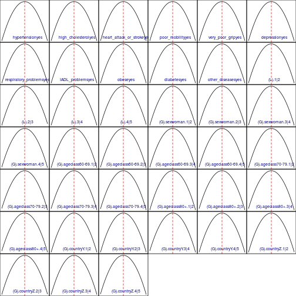

```
## All parameters seem to be at arg.max (at optimum).
```

```r
# check the fit
profile(model1)
```

```r
# Example 2 ---------------------

# incorporating survey design
design <- svydesign(ids = ~ country + psu, weights = healthsurvey$csw,
data = healthsurvey)

model2 <- hopit(latent.formula = health ~ hypertension + high_cholesterol +
                  heart_attack_or_stroke + poor_mobility +
                  very_poor_grip + depression + respiratory_problems +
                  IADL_problems + obese + diabetes + other_diseases,
                thresh.formula = ~ sex + ageclass + country,
                decreasing.levels = TRUE,
                design = design,
                control = list(trace = FALSE),
                data = healthsurvey)

# compare latent variables
cbind('No survey design' = coef(model1, aslist = TRUE)$latent.par,
'Has survey design' = coef(model2, aslist = TRUE)$latent.par)
```

```
##                           No survey design Has survey design
## hypertensionyes                 0.18475332        0.18777955
## high_cholesterolyes             0.08972562        0.09368829
## heart_attack_or_strokeyes       0.34659838        0.34676962
## poor_mobilityyes                0.70346456        0.70603471
## very_poor_gripyes               0.51424418        0.54768793
## depressionyes                   0.24998274        0.24922297
## respiratory_problemsyes         0.37863461        0.37984848
## IADL_problemsyes                0.59262343        0.60999389
## obeseyes                        0.19041874        0.18874130
## diabetesyes                     0.32839067        0.32328477
## other_diseasesyes               0.32936970        0.32876106
```

```r
# Example 3 ---------------------

# using crossinter.formula
model3 <- hopit(latent.formula = health ~ hypertension + high_cholesterol +
                heart_attack_or_stroke + poor_mobility + very_poor_grip +
                depression + respiratory_problems +
                IADL_problems + obese + diabetes + other_diseases,
              thresh.formula = ~ sex + ageclass + country,
              crossinter.formula = ~ sex : depression + sex : diabetes,
              decreasing.levels = TRUE,
              control = list(trace = FALSE),
              data = healthsurvey)

# print the model:
coef(model3, aslist = TRUE)$latent.params
```

```
##           hypertensionyes       high_cholesterolyes
##                0.18453211                0.08933102
## heart_attack_or_strokeyes          poor_mobilityyes
##                0.34621710                0.70418762
##         very_poor_gripyes             depressionyes
##                0.51346264                0.25932129
##   respiratory_problemsyes          IADL_problemsyes
##                0.37873644                0.59218947
##                  obeseyes               diabetesyes
##                0.19023667                0.31153840
##         other_diseasesyes    depressionyes:sexwoman
##                0.32937959               -0.01547785
##      diabetesyes:sexwoman
##                0.03890626
```

```r
# compare fit of model1 and model 3
# Likelihood Ratio Test
anova(model1, model3)
```

```
## Full model:
## -- Formula (latent variables):
## health ~ hypertension + high_cholesterol + heart_attack_or_stroke +
##     poor_mobility + very_poor_grip + depression + respiratory_problems +
##     IADL_problems + obese + diabetes + other_diseases + depression:sex +
##     diabetes:sex
## -- Formula (threshold variables): ~sex + ageclass + country
## -- Theta: FALSE
##
## Nested model:
## -- Formula (latent variables):
## health ~ hypertension + high_cholesterol + heart_attack_or_stroke +
##     poor_mobility + very_poor_grip + depression + respiratory_problems +
##     IADL_problems + obese + diabetes + other_diseases
## -- Formula (threshold variables): ~sex + ageclass + country
## -- Theta: FALSE
##
## Likelihood ratio test:
##  Chi^2 df Pr(>Chi^2)
##  0.344  2      0.842
```

```r
# AIC
AIC(model1, model3)
```

```
##   model1   model3
## 25154.19 25157.84
```

```r
# Example 4 ---------------------

# model with overdispersion
model4 <- hopit(latent.formula = health ~ hypertension + high_cholesterol +
                heart_attack_or_stroke + poor_mobility + very_poor_grip +
                depression + respiratory_problems +
                IADL_problems + obese + diabetes + other_diseases,
              thresh.formula = ~ sex + ageclass + country,
              overdispersion = TRUE,
              decreasing.levels = TRUE,
              control = list(trace = FALSE),
              data = healthsurvey)

# estimated variance of the error term:
getTheta(model4)
```

```
## [1] 1.02647
```

```r
# compare fit of model1 and model4
# Likelihood Ratio Test
print(anova(model1, model4), short = TRUE)
```

```
## Negligible differences between log likelihoods.
```

```
##
## Likelihood ratio test:
##  Chi^2 df Pr(>Chi^2)
##      0  1          1
```

[Package *hopit* version 0.4.167 Index]